# Vehicular Collisions in NYC

October 12, 2016

## Dataset Summary

[NYPD_Motor_Vehicle_Collisions](https://data.cityofnewyork.us/Public-Safety/NYPD-Motor-Vehicle-Collisions/h9gi-nx95) provided by NYC Open Data

This dataset provides insights into the all vehicular collisions within the NYC area

- 902679 observations with 30 variables
- Updated on weekdays (Current data is 07/01/2012 - 10/11/2016)
- Data sourced from the NYPD

## What are we trying to answer?

- Is Vision Zero working? i.e. Is there a decreasing trend?
- Where are the highest number of collisions?
- When? (by Month, by Hour of day)
- Common causes for collisions

## YTD 2016 Vehicular Crashes

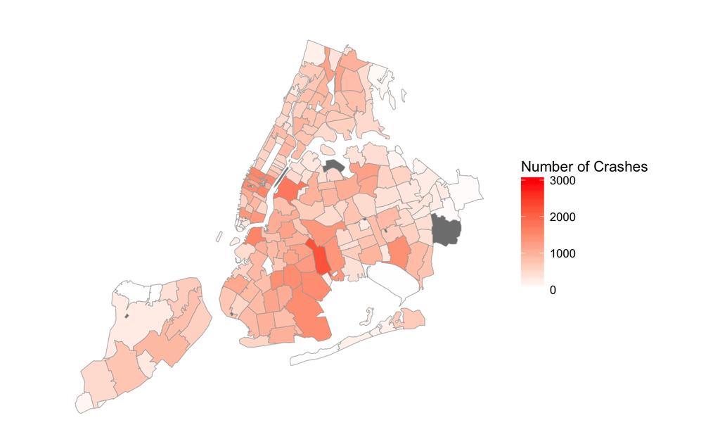

Generated using choroplethrZip library

## Changes from 2013 to 2014

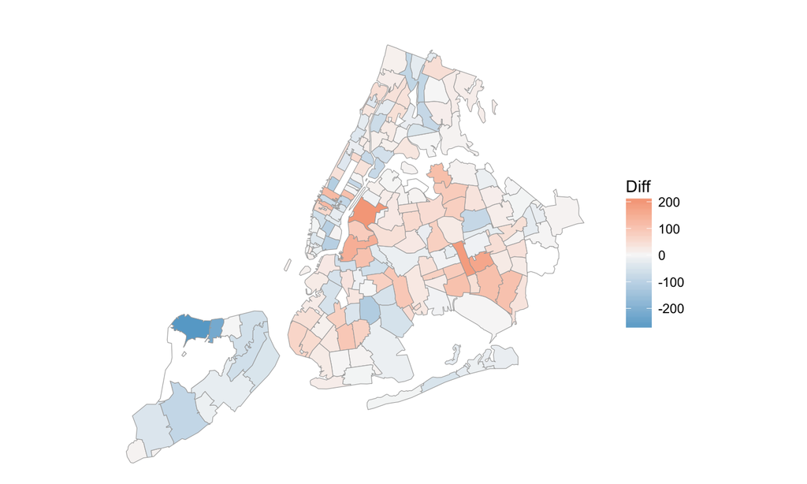

2013 n = 203689; 2014 n = 205929

## Changes from 2014 to 2015

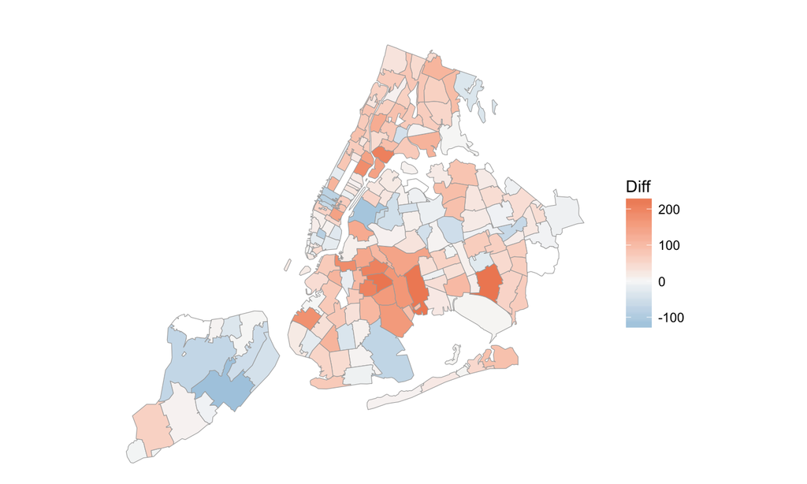

2014 n = 205929; 2015 n = 217539

## Number of Fatal Crashes per Year

| Year | Count of Fatalities |
| --- | --- |
| 2013 | 297 |
| 2014 | 262 |
| 2015 | 243 |

## Fatalities by Borough

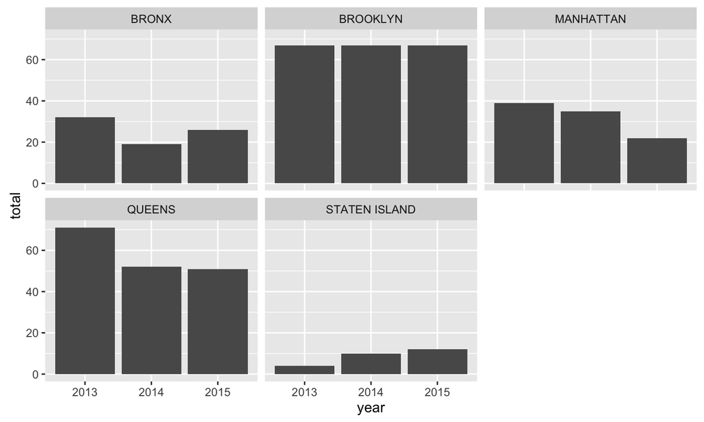

## Vehicular Crashes by Hour of Day

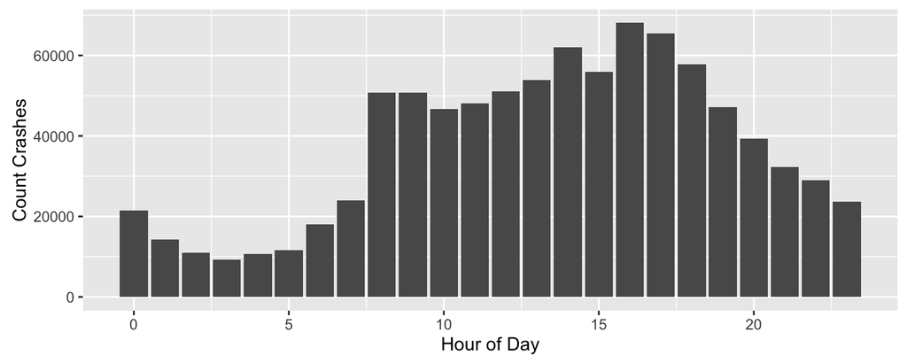

## Vehicular Crashes by Month

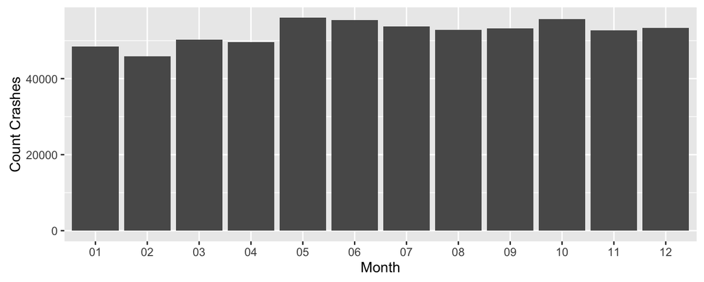

Data from full years of 2013, 2014, 2015

## Top 5 Contributing Factors

| Number | Reason | Count |
| --- | --- | --- |
| 1 | Unspecified | 500826 |
| 2 | Driver Inattention/Distraction | 106757 |
| 3 | Fatigued/Drowsy | 48153 |
| 4 | Failure to Yield Right-of-Way | 36776 |
| 5 | Other Vehicular | 27953 |

15 - Alcohol Involvement  
20 - Aggressive Driving/Road Rage  
42 - Cell Phone (hands-free)  
43 - Cell Phone (hand-held)

## Top 5 Contributing Factors - Fatal Collisions

| Number | Reason | Count |
| --- | --- | --- |
| 1 | Unspecified | 536 |
| 2 | Traffic Control Disregarded | 124 |
| 3 | Driver Inattention/Distraction | 95 |
| 4 | Failure to Yield Right-of-Way | 75 |
| 5 | Passenger Distraction | 52 |

## Conclusions

- Vehicular collisions are on the rise, but fatalities have been decreasing since 2013.
- The Vision Zero initiative may be benefiting certain neighborhoods more than others.
- Collisions most commonly occur during the the hours of 4-6PM.
- Collisions happen most frequently around Manhattan's Midtown, East New York/Carnarsie, and Long Island City.

## Next Steps

- Compare NYC's stats to other cities
- Look at other cities who are doing a Vision Zero initiative and benchmark NYC's progress
- Compare neighborhood median incomes and see if there is a correlation to the improvement from Vision Zero initiatives